# UNIT07D：願付價格與最適定價

中山大學管理學院 卓雍然

2022-03-26 11:59:58

💡 學習重點：  
■ 願付價格(WTP - Willingness to Pay)的分佈  
■ 價量關係：供給曲線與價格反應含數  
■ 使用`fitdistplus::fitdist()`適配(fit)標準機率分佈的模型  
■ 使用`nls()`適配標準機率分佈的模型  
■ 簡單的模擬(Simulation)與優化(Optimization)  
■ 依據願付價格的分佈規劃定價策略

### 1. 願付價格(WTP)的實證分布

把願付價格(WTP - Willingness to Pay)讀進資料框`A`

```r
p_load(dplyr, fitdistrplus)
A = read.csv("data/wtpData.csv")
```

##### § 實證累計機率函數 `ecdf()` - Emperical CDF

直接呼叫`ecdf()`就可以建立實證累計機率函數  
若願付大於價格(`WTP > p`)的消費者都會購買，則價格反應函數：`q(p) = 1 - W(p)`

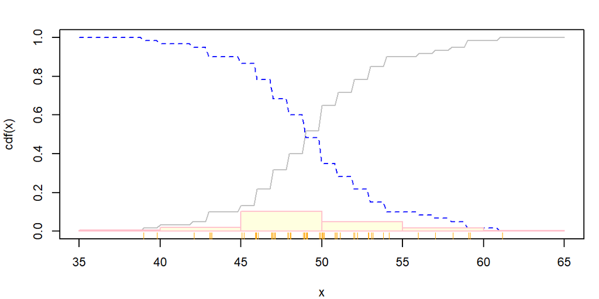

```r
cdf = ecdf(A$Wtp)       # 建立實證累計機率函數
x = seq(35,65,0.2)      # 價格向量

par(mar=c(4,4,2,1), cex=0.75)
plot(x, cdf(x), type='l', col='gray')   # 實證累計機率函數
lines(x, 1-cdf(x),col='blue', lty=2)    # 價格反應函數 q(p) = 1 - W(p)
rug(jitter(A$Wtp),col='orange')         # 數值標記 *w/jitter*
hist(A$Wtp, freq=F, add=T, col='lightyellow',border='pink')  # 直方圖
```

##### § 市場模擬與策略優化

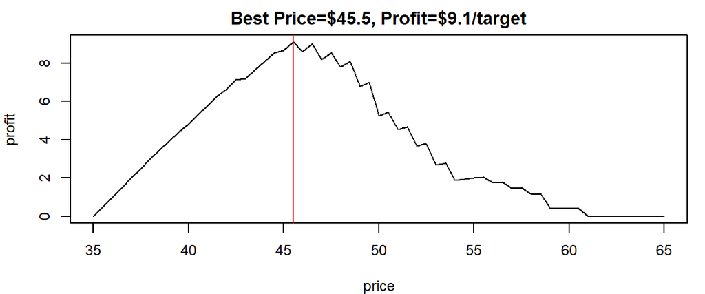

```r
cost = 35                       # 成本
price = seq(35,65,0.5)          # 價格向量
qty = 1 - cdf(price)            # 依據模型估計銷售量
rev = qty * price               # 營收
profit = qty * (price - cost)   # 獲利
i = which.max(profit)           # 最高獲利的索引
par(mar=c(4,4,2,1), cex=0.75)
plot(price, profit, type='l',main=sprintf(
  "Best Price=$%.1f, Profit=$%.1f/target", price[i], profit[i]))
abline(v = price[i], col='red')
```

🗿 直接使用實證數據來做策略規劃，可能會有什麼問題呢？

### 2. 使用實證數據建立模型

##### § 將資料適配(fit)進理論機率分佈

我們可以使用`fitdistplus::fitdist()`適配(fit)標準機率分佈的模型，假設WTP是呈常態分佈 …

```r
Norm = fitdistrplus::fitdist(A$Wtp, "norm")
summary(Norm)
```

```
Fitting of the distribution ' norm ' by maximum likelihood
Parameters :
     estimate Std. Error
mean  49.5167    0.56886
sd     4.4064    0.40225
Loglikelihood:  -174.12   AIC:  352.24   BIC:  356.43
Correlation matrix:
     mean sd
mean    1  0
sd      0  1
```

💡 其實任何理論機率分佈只要形狀類似都可以用，我們也可以試幾個不同的分佈，然後挑最好(依據Loglikelihood、AIC、BIC)的一個。

比如像`norm-al`、`t`、`logis-tic` Distributions 都是鐘形對稱的分佈…

```r
c(fitdist(A$Wtp, "norm")$loglik,
  fitdist(A$Wtp, "logis")$loglik,
  fitdist(A$Wtp, "t", start=list(df=58))$loglik)
```

```
[1] -174.12 -173.52 -435.87
```

##### § 願付價格(WTP)的機率密度函數(pdf)

$w(p) \sim Norm[\mu=49.5, \sigma=4.4]$

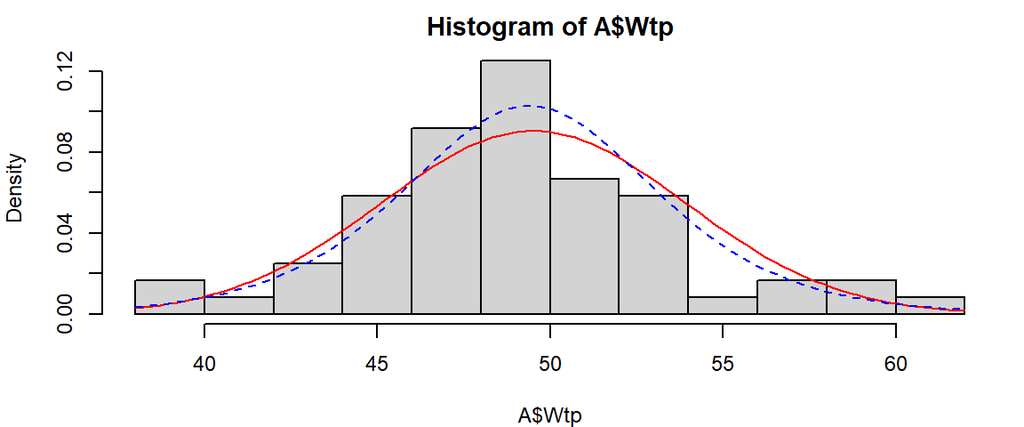

```r
par(mar=c(4,4,2,1), cex=0.75)
hist(A$Wtp, breaks=12, freq=F)

Norm = fitdist(A$Wtp, "norm") # Fit into Normal Dist.
curve(dnorm(x, Norm$esti['mean'], Norm$esti['sd']),
      add=T, col='red')

Logis = fitdist(A$Wtp, "logis")  # Fit into Logistic Dist.
curve(dlogis(x, Logis$esti['location'], Logis$esti['scale']),
      add=T, col='blue', lty=2)
```

##### § 市場模擬與策略優化

然後我們可以用完全相同的方法透過市場模擬找出最適定價

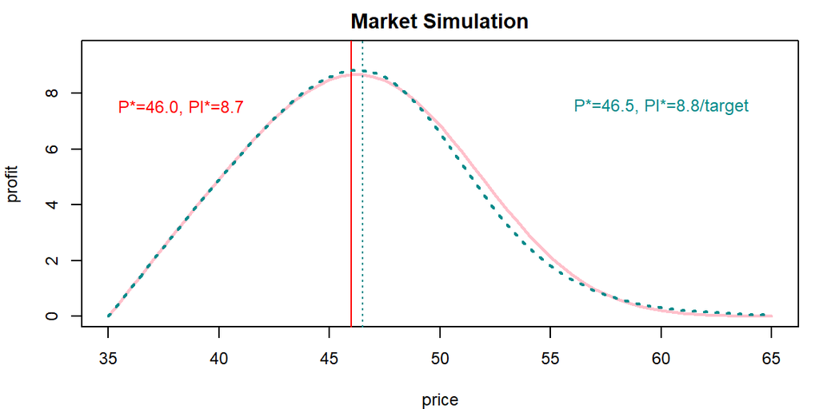

```r
cost = 35                       # 成本
price = seq(35,65,0.5)          # 價格向量

# 依 Normal Dist. 模型估計銷售量
qty = 1 - pnorm(price, Norm$esti['mean'], Norm$esti['sd'])
profit = qty * (price - cost)   # 獲利
i = which.max(profit)           # 最高獲利的索引
par(mar=c(4,4,2,1), cex=0.75)
plot(price, profit, type='l', col='pink', lwd=2, ylim=c(0,9.5),
     main="Market Simulation")
abline(v = price[i], col='red')
text(35,7.5,pos=4,col='red',sprintf(
  "P*=%.1f, PI*=%.1f", price[i], profit[i]))

# 依 Logistic Dist. 模型估計銷售量
qty = 1 - plogis(price, Logis$esti['location'], Logis$esti['scale'])
profit = qty * (price - cost)
i = which.max(profit)
lines(price, profit, col='darkcyan', lwd=2, lty=3)
abline(v = price[i], col='darkcyan',lty=3)
text(60,7,col='darkcyan',pos=3,sprintf(
  "P*=%.1f, PI*=%.1f/target", price[i], profit[i]))
```

### 3. 價格反應曲線回推WTP的分佈

實務上，我們很難估計每個消費者的WTP，行銷人員通常只能挑選一些有代表性的地區、先用以不同的價格來量測價量關係；假設我們以這個方式得到五個資料點，我們可以用它們畫出一條價格反應曲線：$q(p)$

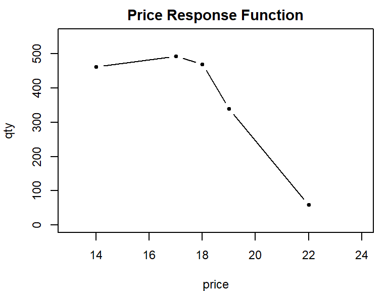

```r
qty = c(461,493,469,339,60)
price = c(14,17,18,19,22)
par(mar=c(4,4,2,1), cex=0.75)
plot(price, qty, type='b', pch=20, ylim=c(0,550), xlim=c(13,24),
     main="Price Response Function")
```

💡 價格反應曲線其實就是 $w(p)$ 分佈的CDF的補數 $q(p) = 1-W(p)$

🗿 那我們如何從價格反應曲線回推願付價格的分佈呢？

##### § 邏輯式分佈 Logistic Dist.

常態分佈CDF的數學式非常複雜，fit起來很困難，邏輯式分佈的CDF相對簡單，而且它和常態分佈的形狀很類似，所以行銷者通常用它來適配價格反應曲線

**Logistic Distribution** :
$$pdf(x)=\frac{exp(-\frac{x-u}{s})}{s(1+exp(-\frac{x-u}{s}))^{2}}
\;\;,\;\;\;\;\;
1-cdf(x)=\frac{1}{1+exp(\frac{x-u}{s})}$$

💡 邏輯式分佈的CDF就是邏輯式函數

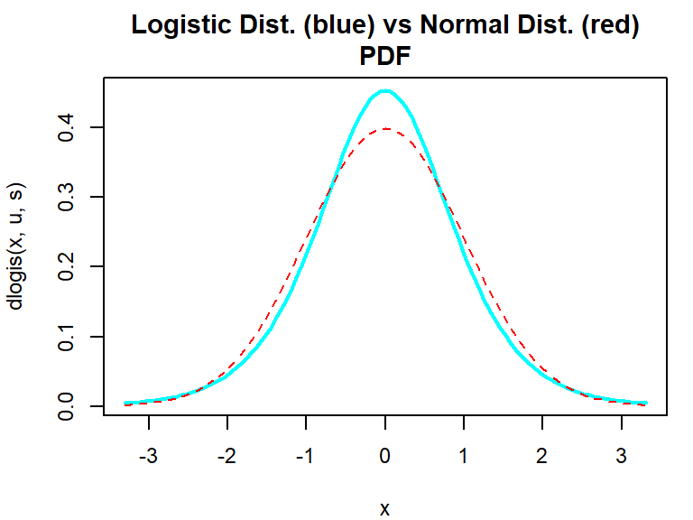

```r
u=0; sd=1; s=sqrt(sd*3/(pi^2))
par(mar=c(4,4,3,1), cex=0.75)
curve(dlogis(x, u, s), u-6*s, u+6*s, col='cyan', lwd=2,
      main="Logistic Dist. (blue) vs Normal Dist. (red)\nPDF")
curve(dnorm(x,u,sd), col='red', lty=2, add=T)
```

##### § 參數估計與轉換

從價格反應曲線$q(p)$，我們可以觀察出相對應的常態分佈參數：$\mu \simeq 20, \sigma \simeq 1$；  
然後我們可以利用**參數轉換公式**(Normal to Logistic Dist.)：

- mean $u = \mu$
- scale $s = \sqrt{\frac{3 \sigma^2}{\pi^2}}$

估計邏輯式分佈的參數：

```r
u = 20
s = sqrt(3 * 1^2 / pi^2)
```

##### § 模型適配

然後我們可以用`stats::nls()`這個功能將價格反應曲線$q(p)$適配進邏輯式分佈的CDF

```r
mod = nls(qty ~ N/(1+exp((price - u)/s)), start=c(N=500, u=u, s=s) )
coef(mod)
```

```
        N         u         s
490.61651  19.93439   0.89355
```

##### § 繪製模型

取出模型係數，就可以畫出模型

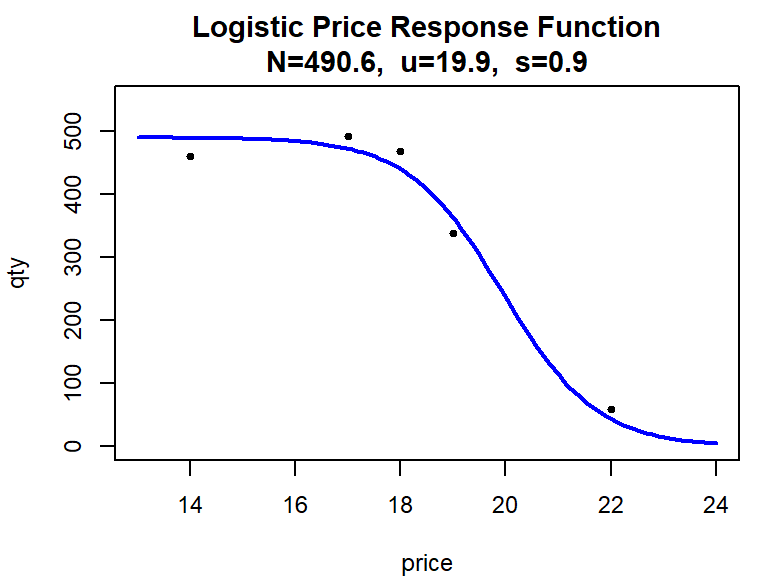

```r
N = coef(mod)[1]; u = coef(mod)[2]; s = coef(mod)[3]
par(mar=c(4,4,3,1), cex=0.75)
plot(price, qty, pch=20, ylim=c(0,550), xlim=c(13,24), main=sprintf(
  "Logistic Price Response Function\nN=%.1f,  u=%.1f,  s=%.1f",
  N, u, s))
curve(N/(1+exp((x-u)/s)), col='blue', lwd=2, add=T)
```

##### § 策略模擬

一旦知道邏輯式分佈的參數，我們就可以使用標準的機率分佈功能`plogis(x,u,s)`來做策略模擬 …

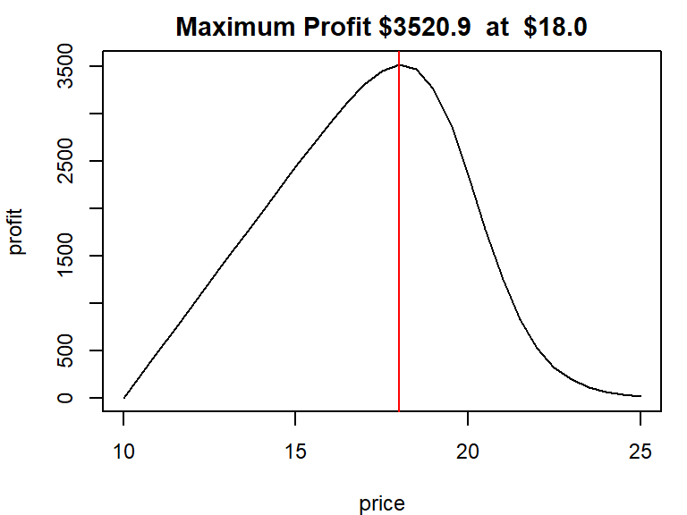

```r
cost = 10
price = seq(10,25,0.5)
qty = N * (1 - plogis(price, u, s))
rev = qty * price
profit = qty * (price - cost)
i = which.max(profit)
par(mar=c(4,4,2,1), cex=0.75)
plot(price, profit, type='l', main=sprintf(
  "Maximum Profit $%.1f  at  $%.1f", profit[i], price[i]))
abline(v=price[i], col='red')
```

💡 商務數據分析：結合商務、機率與程式的策略規劃過程